# EDS 223: assignment 3

Andrew Bartnik

2022-10-26

## Overview

“In February 2021, the state of Texas suffered a major power crisis, which came about as a result of three severe winter storms sweeping across the United States on February 10–11, 13–17, and 15–20.”[^1] For more background, check out these [engineering](https://www.youtube.com/watch?v=08mwXICY4JM&ab_channel=PracticalEngineering) and [political](https://www.youtube.com/watch?v=Zcrsgdl_hP0&ab_channel=Vox) perspectives.

For this assignment, you are tasked with:  
- estimating the number of homes in Houston that lost power as a result of the first two storms  
- investigating if socioeconomic factors are predictors of communities recovery from a power outage

Your analysis will be based on remotely-sensed night lights data, acquired from the [Visible Infrared Imaging Radiometer Suite (VIIRS)](https://en.wikipedia.org/wiki/Visible_Infrared_Imaging_Radiometer_Suite) onboard the Suomi satellite. In particular, you will use the VNP46A1 to detect differences in night lights before and after the storm to identify areas that lost electric power.

To determine the number of homes that lost power, you link (spatially join) these areas with [OpenStreetMap](https://www.openstreetmap.org/#map=4/38.01/-95.84) data on buildings and roads.

To investigate potential socioeconomic factors that influenced recovery, you will link your analysis with data from the US Census Bureau.

##### Learning objectives:

- load vector/raster data
- simple raster operations
- simple vector operations
- spatial joins

### Data

#### Night lights

Use NASA’s Worldview to explore the data around the day of the storm. There are several days with too much cloud cover to be useful, but 2021-02-07 and 2021-02-16 provide two clear, contrasting images to visualize the extent of the power outage in Texas.

VIIRS data is distributed through NASA’s [Level-1 and Atmospheric Archive & Distribution System Distributed Active Archive Center (LAADS DAAC)](https://ladsweb.modaps.eosdis.nasa.gov/). Many NASA Earth data products are distributed in 10x10 degree tiles in sinusoidal equal-area projection. Tiles are identified by their horizontal and vertical position in the grid. Houston lies on the border of tiles h08v05 and h08v06. We therefore need to download two tiles per date.

As you’re learning in EDS 220, accessing, downloading, and preparing remote sensing data is a skill in it’s own right! To prevent this assignment from being a large data wrangling challenge, we have downloaded and prepped the following files for you to work with, stored in the `VNP46A1` folder.

- `VNP46A1.A2021038.h08v05.001.2021039064328.h5.tif`: tile h08v05, collected on 2021-02-07
- `VNP46A1.A2021038.h08v06.001.2021039064329.h5.tif`: tile h08v06, collected on 2021-02-07
- `VNP46A1.A2021047.h08v05.001.2021048091106.h5.tif`: tile h08v05, collected on 2021-02-16
- `VNP46A1.A2021047.h08v06.001.2021048091105.h5.tif`: tile h08v06, collected on 2021-02-16

#### Roads

Typically highways account for a large portion of the night lights observable from space (see Google’s [Earth at Night](https://earth.google.com/web/@27.44405464,-84.7693044,206.63660162a,8916361.52264659d,35y,0h,0t,0r/data=CiQSIhIgMGY3ZTJkYzdlOGExMTFlNjk5MGQ2ZjgxOGQ2OWE2ZTc)). To minimize falsely identifying areas with reduced traffic as areas without power, we will ignore areas near highways.

[OpenStreetMap (OSM)](https://planet.openstreetmap.org/) is a collaborative project which creates publicly available geographic data of the world. Ingesting this data into a database where it can be subsetted and processed is a large undertaking. Fortunately, third party companies redistribute OSM data. We used [Geofabrik’s download sites](https://download.geofabrik.de/) to retrieve a shapefile of all highways in Texas and prepared a Geopackage (`.gpkg` file) containing just the subset of roads that intersect the Houston metropolitan area.

- `gis_osm_roads_free_1.gpkg`

#### Houses

We can also obtain building data from OpenStreetMap. We again downloaded from Geofabrick and prepared a GeoPackage containing only houses in the Houston metropolitan area.

- `gis_osm_buildings_a_free_1.gpkg`

#### Socioeconomic

We cannot readily get socioeconomic information for every home, so instead we obtained data from the [U.S. Census Bureau’s American Community Survey](https://www.census.gov/programs-surveys/acs) for census tracts in 2019. The *folder* `ACS_2019_5YR_TRACT_48.gdb` is an ArcGIS [“file geodatabase”](https://desktop.arcgis.com/en/arcmap/latest/manage-data/administer-file-gdbs/file-geodatabases.htm), a multi-file proprietary format that’s roughly analogous to a GeoPackage file.

You can use `st_layers()` to explore the contents of the geodatabase. Each layer contains a subset of the fields documents in the [ACS metadata](https://www2.census.gov/geo/docs/maps-data/data/tiger/prejoined/ACSMetadata2011.txt).

The geodatabase contains a layer holding the geometry information, separate from the layers holding the ACS attributes. You have to combine the geometry with the attributes to get a feature layer that `sf` can use.

## Assignment

Below is an outline of the steps you should consider taking to achieve the assignment tasks.

```r
#loading libraries
library(terra)
library(spData)
library(spDataLarge)
library(tmap)
library(dplyr)
library(stars)
```

```r
library(ggplot2)
```

#### Find locations of blackouts

For improved computational efficiency and easier interoperability with `sf`, I recommend using the `stars` package for raster handling.

##### combine the data (5 points)

- read in night lights tiles
- combine tiles into a single `stars` object for each date (2021-02-07 and 2021-02-16)
  - hint: use `st_mosaic`

```r
#reading in first tile from feb 7th
feb7_1 <-  rast('data/VNP46A1/VNP46A1.A2021038.h08v05.001.2021039064328.tif') |>
  st_as_stars()
#reading in second tile from feb 7th
feb7_2 <- rast('data/VNP46A1/VNP46A1.A2021038.h08v06.001.2021039064329.tif') |>
  st_as_stars()

#combining tiles from feb 7th
feb7_mosaic <- st_mosaic(feb7_1, feb7_2)


#doing the same with first and second tiles from feb 16th
feb16_1 <- rast('data/VNP46A1/VNP46A1.A2021047.h08v05.001.2021048091106.tif') |>
  st_as_stars()

feb16_2 <- rast('data/VNP46A1/VNP46A1.A2021047.h08v06.001.2021048091105.tif') |>
  st_as_stars()


#combining them
feb16_mosaic <- st_mosaic(feb16_1, feb16_2)
```

```
## downsample set to 6
```

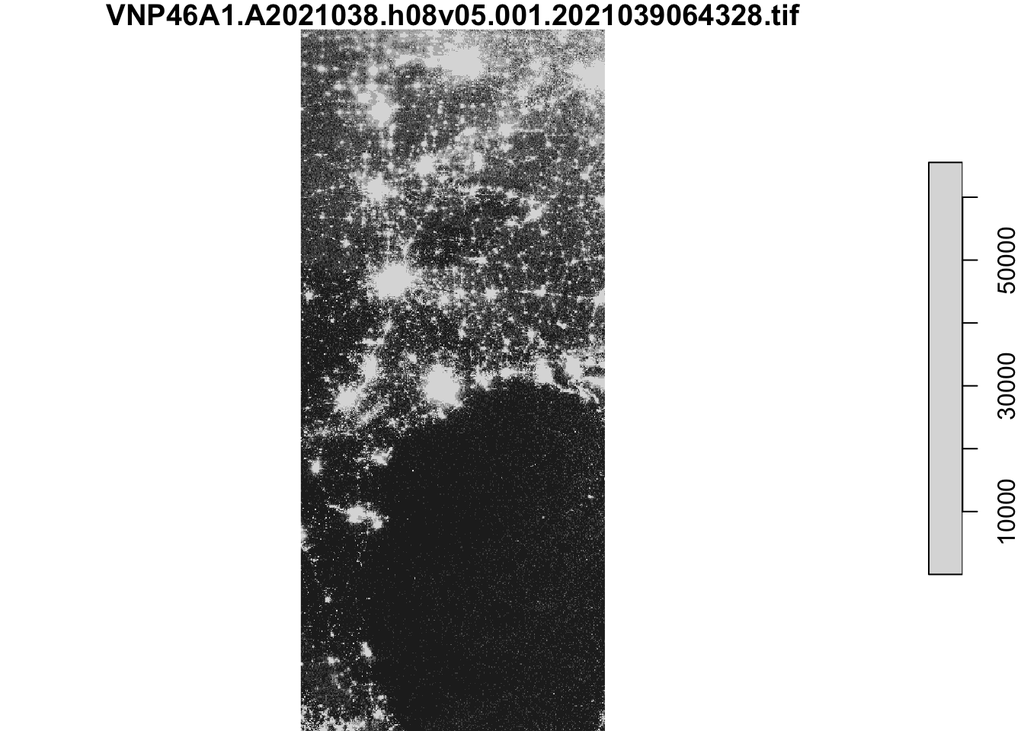

```r
#sanity check
plot(feb7_mosaic)
```

```
## downsample set to 6
```

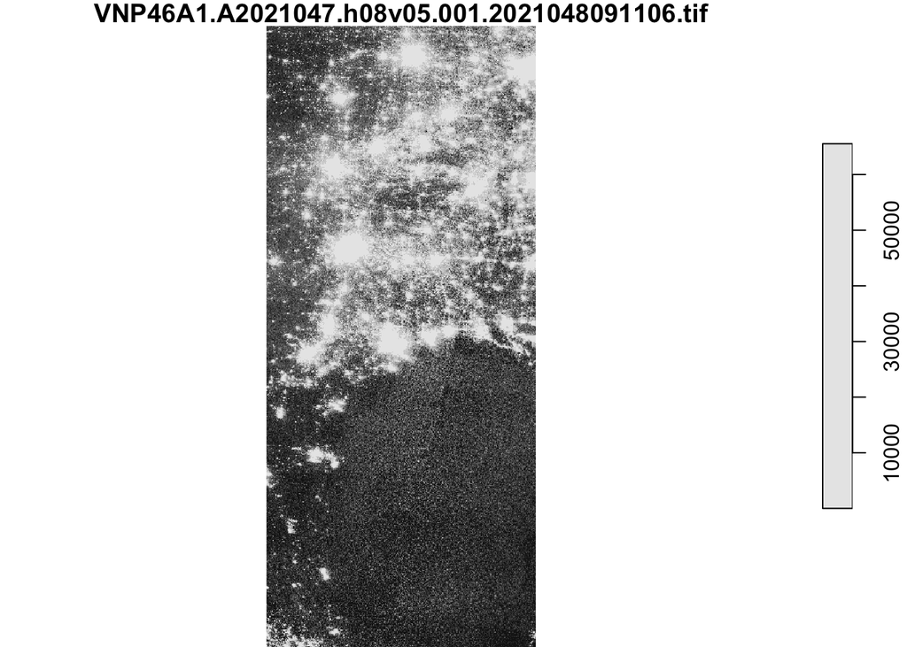

```r
plot(feb16_mosaic)
```

##### create a blackout mask (10 points)

- find the change in night lights intensity (presumably) caused by the storm
- reclassify the difference raster, assuming that any location that experienced a drop of more than 200 nW cm<sup>-2</sup>sr<sup>-1</sup> experienced a blackout
- assign `NA` to all locations that experienced a drop of *less* than 200 nW cm<sup>-2</sup>sr<sup>-1</sup>

```
## downsample set to 6
```

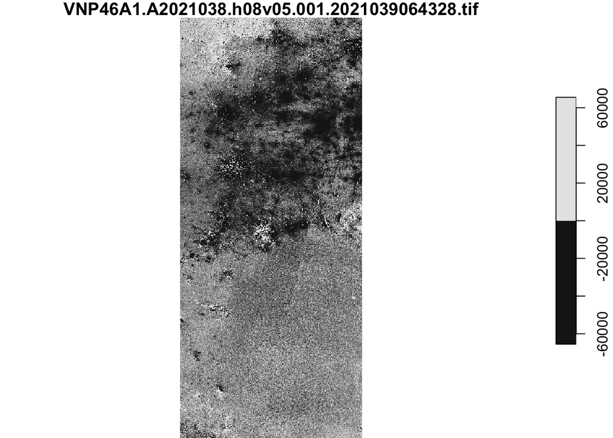

```r
#finding the change in night lights intensity - see what we get
difference_lights <- feb7_mosaic - feb16_mosaic
plot(difference_lights)
```

```
## downsample set to 6
```

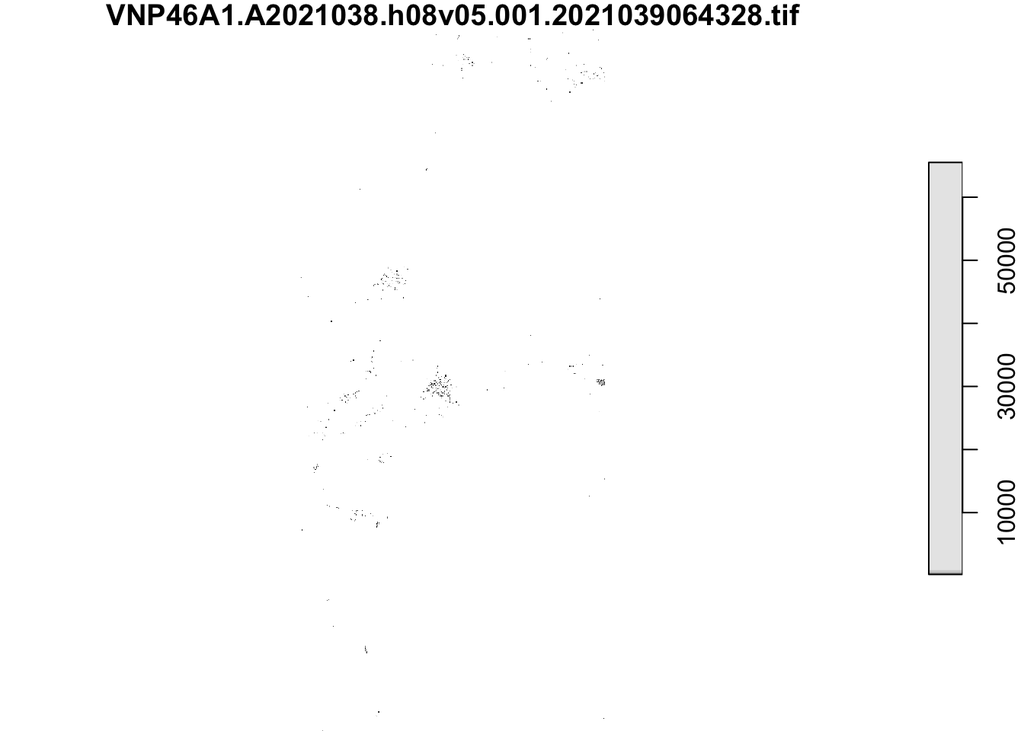

```r
#reclassify difference raster - assign NAs to all points experiencing a drop less than 200
difference_lights[difference_lights < 200] <-  NA
plot(difference_lights)
```

##### vectorize the mask (5 points)

- use `st_as_sf()` to vectorize the blackout mask
- fix any invalid geometries using `st_make_valid`

```r
#vectorize the blackout mask
blackout_mask <- st_as_sf(difference_lights) |>
  st_make_valid()
```

##### crop the vectorized map to our region of interest (10 points)

- define the Houston metropolitan area with the following coordinates
  - (-96.5, 29), (-96.5, 30.5), (-94.5, 30.5), (-94.5, 29)
- turn these coordinates into a polygon using `st_polygon`
- convert the polygon into a simple feature collection using `st_sfc()` and assign a CRS
  - hint: because we are using this polygon to crop the night lights data it needs the same CRS
- crop (spatially subset) the blackout mask to our region of interest
- re-project the cropped blackout dataset to EPSG:3083 (NAD83 / Texas Centric Albers Equal Area)

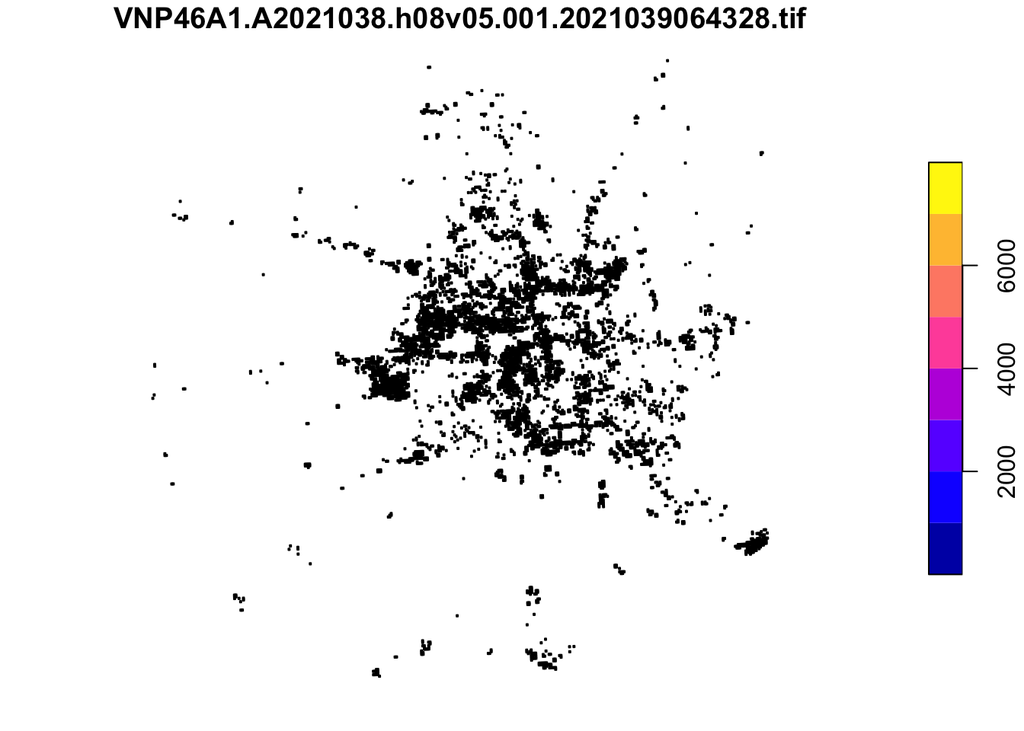

```r
#defining houston coordinates
houston <- cbind(x = c(-96.5, -96.5, -94.5, -94.5, -96.5),
                         y = c(29, 30.5, 30.5, 29, 29))
#turning coordinates into polygon
houston <- st_sfc(st_polygon(list(houston)), crs = 4326)

#subsetting and masking houston
mask <- st_intersects(blackout_mask, houston, sparse = FALSE)
houston_subset <- blackout_mask[mask,]

#reprojecting
houston_reproj <- st_transform(houston_subset, crs = 3083)
plot(houston_reproj)
```

##### exclude highways from blackout mask (10 points)

The roads geopackage includes data on roads other than highways. However, we can avoid reading in data we don’t need by taking advantage of `st_read`’s ability to subset using a SQL query.

- define SQL query
- load just highway data from geopackage using `st_read`
- reproject data to EPSG:3083
- identify areas within 200m of all highways using `st_buffer`
  - hint: `st_buffer` produces undissolved buffers, use `st_union` to dissolve them
- find areas that experienced blackouts that are further than 200m from a highway

`query <- "SELECT * FROM gis_osm_roads_free_1 WHERE fclass='motorway'"`  
`highways <- st_read("data/gis_osm_roads_free_1.gpkg", query = query)`

```r
#Loading highway data + querying
query <- "SELECT * FROM gis_osm_roads_free_1 WHERE fclass='motorway'"
highways <- st_read("data/gis_osm_roads_free_1.gpkg", query = query)
```

```
## Reading query `SELECT * FROM gis_osm_roads_free_1 WHERE fclass='motorway'' from data source `/Users/andrewbartnik/Desktop/MEDS/fall/spatial_analysis/homework/assignment3-andrewbartnik/data/gis_osm_roads_free_1.gpkg'
##   using driver `GPKG'
## Simple feature collection with 6085 features and 10 fields
## Geometry type: LINESTRING
## Dimension:     XY
## Bounding box:  xmin: -96.50429 ymin: 29.00174 xmax: -94.39619 ymax: 30.50886
## Geodetic CRS:  WGS 84
```

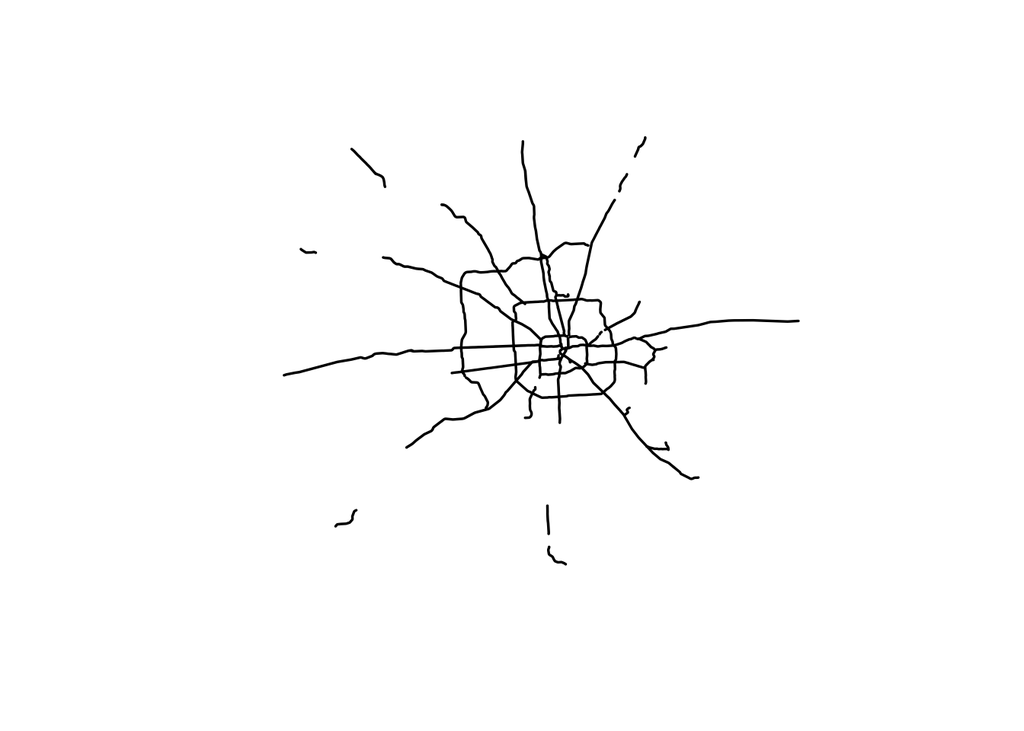

```r
#reprojecting highways
highways_reproject <- st_transform(highways, crs = 3083)

#making undissolved buffers
highway_buffer <- st_union(st_buffer(highways_reproject, dist = 200))
plot(highway_buffer)
```

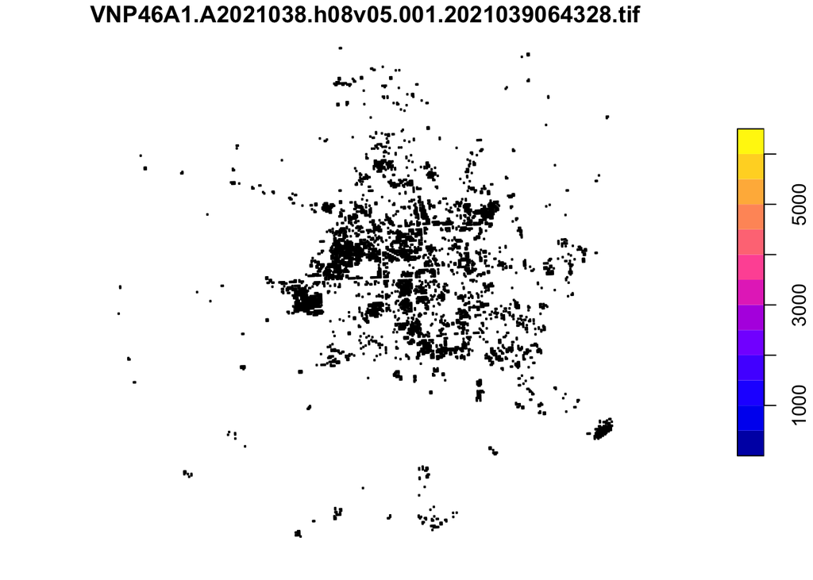

```r
#plot area outside buffer
highway_blackouts <- houston_reproj[highway_buffer, op = st_disjoint]
plot(highway_blackouts)
```

#### Find homes impacted by blackouts

##### load buildings data (10 points)

- load buildings dataset using `st_read` and the following SQL query to select only residential buildings
- hint: reproject data to EPSG:3083

`SELECT *` `FROM gis_osm_buildings_a_free_1`  
`WHERE (type IS NULL AND name IS NULL)`  
`OR type in ('residential', 'apartments', 'house', 'static_caravan', 'detached')`

```r
query2 <- "SELECT * FROM gis_osm_buildings_a_free_1 WHERE (type IS NULL AND name IS NULL)OR type in ('residential', 'apartments', 'house', 'static_caravan', 'detached')"
buildings_file <- st_read('data/gis_osm_buildings_a_free_1.gpkg', query = query2)
```

```
## Reading query `SELECT * FROM gis_osm_buildings_a_free_1 WHERE (type IS NULL AND name IS NULL)OR type in ('residential', 'apartments', 'house', 'static_caravan', 'detached')' from data source `/Users/andrewbartnik/Desktop/MEDS/fall/spatial_analysis/homework/assignment3-andrewbartnik/data/gis_osm_b…
##   using driver `GPKG'
## Simple feature collection with 475941 features and 5 fields
## Geometry type: MULTIPOLYGON
## Dimension:     XY
## Bounding box:  xmin: -96.50055 ymin: 29.00344 xmax: -94.53285 ymax: 30.50393
## Geodetic CRS:  WGS 84
```

```r
buildings <- st_transform(buildings_file, crs = 3083)
```

##### find homes in blackout areas (20 points)

- filter to homes within blackout areas
- count number of impacted homes

```r
#removing the buffered highways from the aoi
crop <- st_difference(houston_reproj, highway_buffer)
#subsetting here gives us all buildings>200m away from a highway that experienced a blackout
buildings_blackout <- buildings[crop, op = st_intersects]

#counting the number of residential buildings that got hit - 157970
print(paste0(nrow(buildings_blackout), ' buildings were affected by the blackouts'))
```

```
## [1] "157970 buildings were affected by the blackouts"
```

#### Investigate socioeconomic factors

##### ACS data (10 points)

- use `st_read()` to load the geodatabase layers
- geometries are stored in the `ACS_2019_5YR_TRACT_48_TEXAS` layer
- income data is stored in the `X19_INCOME` layer
- select the median income field `B19013e1`
- hint: reproject data to EPSG:3083

```r
#reading in data and layers that we want
census_geodata <- st_read('data/ACS_2019_5YR_TRACT_48_TEXAS.gdb',
                   layer = 'ACS_2019_5YR_TRACT_48_TEXAS')
census_geodata <- st_transform(census_geodata, crs = 3083)

#reading in income data
geodata_income <- st_read('data/ACS_2019_5YR_TRACT_48_TEXAS.gdb',
                   layer = 'X19_INCOME') |>
  select(GEOID, income = B19013e1)
```

##### determine which census tracts experienced blackouts (10 points)

- join the income data to the census tract geometries
- hint: make sure to join by geometry ID
- spatially join census tract data with buildings determined to be impacted by blackouts
- find which census tracts had blackouts

```r
#join
census_income <- left_join(census_geodata, geodata_income, by = c('GEOID_Data' = "GEOID"))

#transform crs
census_income <- st_transform(census_income, crs = 3083)

# #Which tracts had blackouts?
data_blackouts <- st_join(buildings_blackout, census_income) |>
  mutate(blackout_present = if_else(is.na(osm_id), 0, 1))
data_blackouts |> group_by(TRACTCE)
```

```
## Simple feature collection with 158053 features and 22 fields
## Geometry type: MULTIPOLYGON
## Dimension:     XY
## Bounding box:  xmin: 1843966 ymin: 7218315 xmax: 2006724 ymax: 7376476
## Projected CRS: NAD83 / Texas Centric Albers Equal Area
## # A tibble: 158,053 × 23
## # Groups:   TRACTCE [756]
##    osm_id    code fclass name  type  STATEFP COUNT…¹ TRACTCE GEOID NAME  NAMEL…²
##    <chr>    <int> <chr>  <chr> <chr> <chr>   <chr>   <chr>   <chr> <chr> <chr>
##  1 15289869  1500 build… <NA>  <NA>  48      201     551500  4820… 5515  Census…
##  2 29382948  1500 build… <NA>  <NA>  48      201     240100  4820… 2401  Census…
##  3 29382954  1500 build… <NA>  <NA>  48      201     240100  4820… 2401  Census…
##  4 30280267  1500 build… <NA>  apar… 48      201     452201  4820… 4522… Census…
##  5 30280271  1500 build… <NA>  apar… 48      201     452201  4820… 4522… Census…
##  6 30280274  1500 build… <NA>  <NA>  48      201     452201  4820… 4522… Census…
##  7 30280282  1500 build… <NA>  apar… 48      201     452201  4820… 4522… Census…
##  8 30280291  1500 build… <NA>  apar… 48      201     452201  4820… 4522… Census…
##  9 30280301  1500 build… <NA>  apar… 48      201     452201  4820… 4522… Census…
## 10 30280302  1500 build… <NA>  apar… 48      201     452201  4820… 4522… Census…
## # … with 158,043 more rows, 12 more variables: MTFCC <chr>, FUNCSTAT <chr>,
## #   ALAND <dbl>, AWATER <dbl>, INTPTLAT <chr>, INTPTLON <chr>,
## #   Shape_Length <dbl>, Shape_Area <dbl>, GEOID_Data <chr>, income <dbl>,
## #   geom <MULTIPOLYGON [m]>, blackout_present <dbl>, and abbreviated variable
## #   names ¹COUNTYFP, ²NAMELSAD
```

```r
#Buildings that didn't have any blackouts- manually used an anti-join
no_blackouts <- sapply(st_intersects(buildings, data_blackouts), function(x){length(x) == 0})
no_blackouts_2 <- buildings[no_blackouts,]
```

##### compare incomes of impacted tracts to unimpacted tracts (10 points)

```r
#plotting the buildings affected
blackout_buildings <- buildings_blackout[census_income,]

b2 <- census_income[buildings_blackout,]

#using our region we defined earlier + osm function to rasterize the bounding box
bounding_box <- st_bbox(houston)
houston_map2 <- rosm::osm.raster(bounding_box)
```

```
## Zoom: 9
```

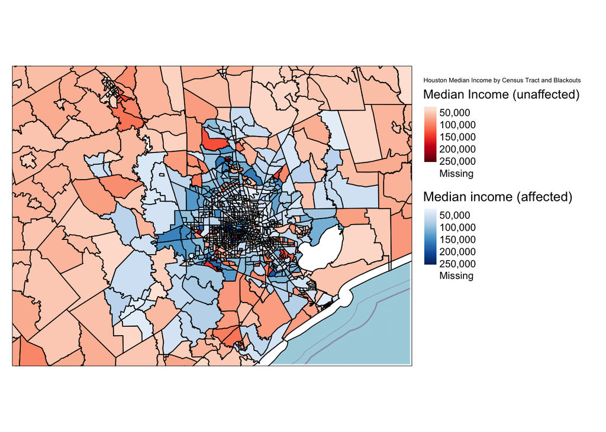

```r
#now for the map
tm_shape(houston_map2) + tm_rgb() +
  tm_shape(census_income, bbox = bounding_box) +
  tm_polygons(col = 'income',
              colorNA = 'white',
              title = 'Median Income (unaffected)',
              palette= 'Reds',
              style = 'cont') +
  tm_shape(b2, bbox = bounding_box) +
  tm_style('col_blind') +
  tm_polygons(col = 'income',
              title = 'Median income (affected)',
              palette = 'Blues',
              style = 'cont') +
  tm_layout('Houston Median Income by Census Tract and Blackouts', legend.outside = TRUE)
```

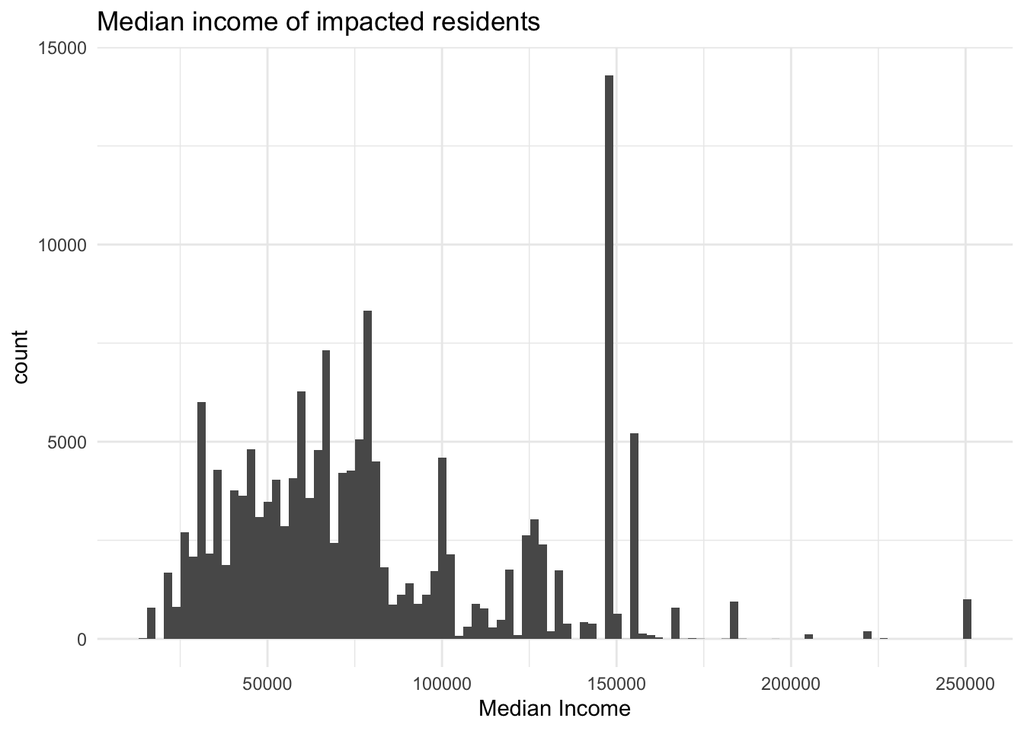

```r
#distributions - impacted
impacted <- data_blackouts[buildings_blackout, op = st_intersects]
ggplot(data = impacted, aes(x = income)) + geom_histogram(bins = 100) + labs(title = 'Median income of impacted residents', x = 'Median Income', y = 'count') + theme_minimal()
```

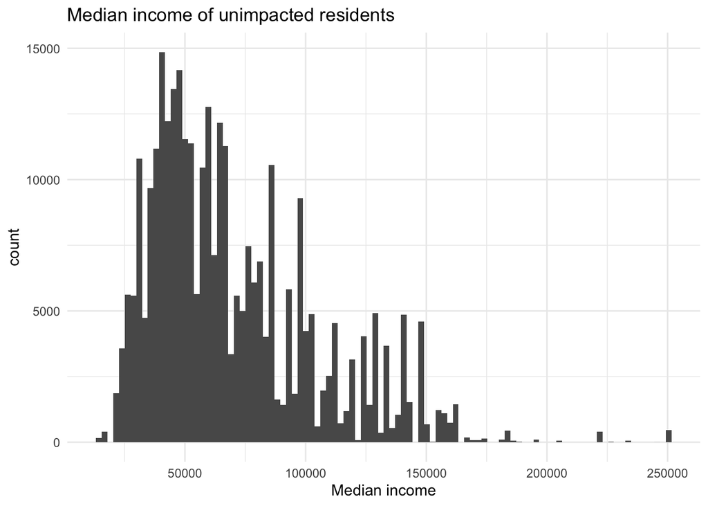

```r
#income dist - unimpacted
unimpacted <- st_join(no_blackouts_2, census_income, join = st_intersects)
ggplot(data = unimpacted, aes(x = income)) + geom_histogram(bins = 100) + labs(title = 'Median income of unimpacted residents', x = 'Median income', y = 'count') + theme_minimal()
```

[^1]: Wikipedia. 2021. “2021 Texas power crisis.” Last modified October 2, 2021. https://en.wikipedia.org/wiki/2021_Texas_power_crisis.